# Introduction to the climate package

Bartosz Czernecki, Arkadiusz Głogowski, Jakub Nowosad

2021-01-07

The goal of the **climate** R package is to automatize downloading of meteorological and hydrological data from publicly available repositories:

- OGIMET [(ogimet.com)](http://ogimet.com/index.phtml.en)
- University of Wyoming - atmospheric vertical profiling data (http://weather.uwyo.edu/upperair/).
- Polish Institute of Meterology and Water Management - National Research Institute [(IMGW-PIB)](https://dane.imgw.pl/)
- National Oceanic & Atmospheric Administration - Earth System Research Laboratory - Global Monitoring Division [(NOAA)](https://www.esrl.noaa.gov/gmd/ccgg/trends/)
- National Oceanic & Atmospheric Administration - National Climatic Data Center - Integrated Surface Hourly (ISH) [(NOAA)](https://www1.ncdc.noaa.gov/pub/data/noaa/)

## Functions

### Meteorological data

- **meteo_ogimet()** - Downloading hourly and daily meteorological data from the SYNOP stations available in the ogimet.com collection. Any meteorological (aka SYNOP) station working under the World Meteorological Organizaton framework after year 2000 should be accessible.
- **meteo_imgw()** - Downloading hourly, daily, and monthly meteorological data from the SYNOP/CLIMATE/PRECIP stations available in the dane.imgw.pl collection. It is a wrapper for `meteo_monthly()`, `meteo_daily()`, and `meteo_hourly()` from [the **imgw** package](https://github.com/bczernecki/imgw).
- **meteo_noaa_hourly()** - Downloading hourly NOAA Integrated Surface Hourly (ISH) meteorological data - Some stations have > 100 years long history of observations
- **sounding_wyoming()** - Downloading measurements of the vertical profile of atmosphere (aka rawinsonde data)

### Hydrological data

- **hydro_imgw()** - Downloading hourly, daily, and monthly hydrological data from the SYNOP / CLIMATE / PRECIP stations available in the danepubliczne.imgw.pl collection. It is a wrapper for `hydro_annual()`, `hydro_monthly()`, and `hydro_daily()` from [the **imgw** package](https://github.com/bczernecki/imgw).

### Auxiliary functions and datasets

- **stations_ogimet()** - Downloading information about all stations available in the selected country in the Ogimet repository
- **nearest_stations_ogimet()** - Downloading information about nearest stations to the selected point available for the selected country in the Ogimet repository
- **imgw_meteo_stations** - Built-in metadata from the IMGW-PIB repository for meteorological stations, their geographical coordinates, and ID numbers
- **imgw_hydro_stations** - Built-in metadata from the IMGW-PIB repository for hydrological stations, their geographical coordinates, and ID numbers
- **imgw_meteo_abbrev** - Dictionary explaining variables available for meteorological stations (from the IMGW-PIB repository)
- **imgw_hydro_abbrev** - Dictionary explaining variables available for hydrological stations (from the IMGW-PIB repository)

## Examples

Examples shows aplication of climate package with additional use of tools that help with processing the data to increase legible of downloaded data.

- dplyr
- tidyr

### Example 1

Finding a 50 nearest meteorological stations in a given country:

```r
library(climate)
ns = nearest_stations_ogimet(country ="United+Kingdom",
                             point = c(-4, 56),
                             no_of_stations = 50,
                             add_map = TRUE)
```

```
#> [1] "http://ogimet.com/cgi-bin/gsynres?lang=en&state=United+Kingdom&osum=no&fmt=html&ord=REV&ano=2021&mes=01&day=07&hora=06&ndays=1&Send=send"
#> /var/folders/lw/3fnnk87n4q1dkl35s2_p24h80000gn/T//Rtmpq8xNfP/file6d01d0c6752
```

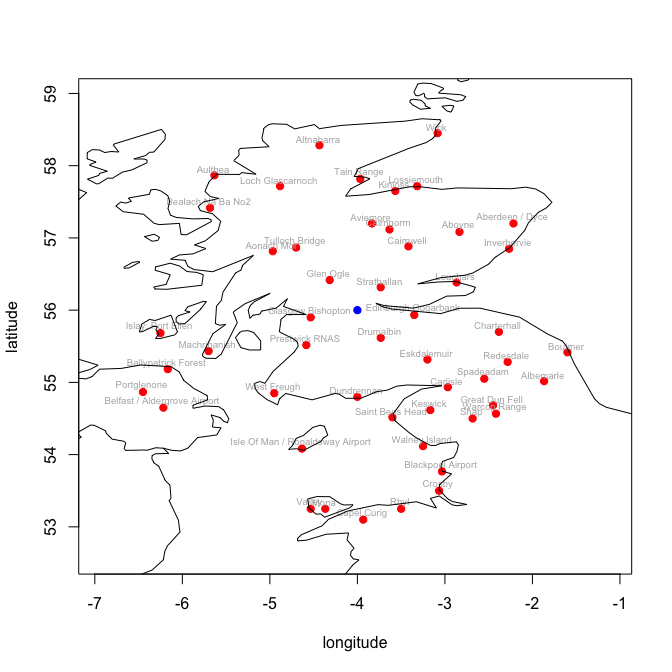

```r
head(ns)
```

[output not shown]

### Example 2

Summary of stations available in Ogimet repository for a selected country:

```r
library(climate)
PL = stations_ogimet(country ="Poland", add_map = TRUE)
```

```
#> [1] "http://ogimet.com/cgi-bin/gsynres?lang=en&state=Poland&osum=no&fmt=html&ord=REV&ano=2021&mes=01&day=07&hora=06&ndays=1&Send=send"
#> /var/folders/lw/3fnnk87n4q1dkl35s2_p24h80000gn/T//Rtmpq8xNfP/file6d02a740339
```

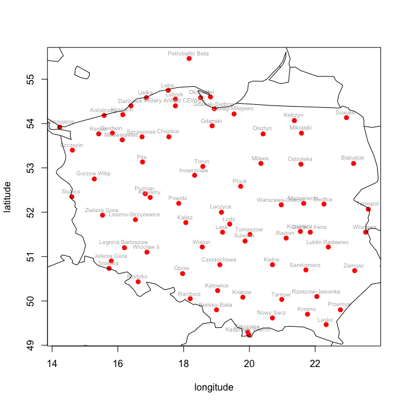

```r
head(PL)
```

```
#>   wmo_id     station_names      lon      lat alt
#> 1  12001 Petrobaltic Beta  18.16667 55.46668  46
#> 2  12100        Kolobrzeg  15.58334 54.18334   3
#> 3  12105         Koszalin  16.15000 54.20000  32
#> 4  12115            Ustka  16.86668 54.58335   6
#> 5  12120             Leba  17.53334 54.75001   2
#> 6  12124         Darlowek  16.40001 54.40001   2
```

### Example 3

```r
# downloading data with NOAA service:
df = meteo_noaa_hourly(station = "010080-99999",
                       year = sample(2000:2020, 1))
```

```
#> [1] "https://www1.ncdc.noaa.gov/pub/data/noaa/2005/010080-99999-2005.gz"
#> /var/folders/lw/3fnnk87n4q1dkl35s2_p24h80000gn/T//Rtmpq8xNfP/file6d072d8092
```

```r
# downloading the same data with Ogimet.com (example for 2019):
# df <- meteo_ogimet(interval = "hourly", date = c("2019-01-01", "2019-12-31"),
#                   station = c("01008"))
```

Examplary data frame of meteorological data.

|  | date | lon | lat | alt | t2m | dpt2m | ws | wd | slp | visibility |
| --- | --- | --- | --- | --- | --- | --- | --- | --- | --- | --- |
| 1 | 2005-01-01 00:00:00 | 15.467 | 78.25 | 29 | -6.0 | -7.5 | 1 | 120 | 976.3 | 75000 |
| 4 | 2005-01-01 02:00:00 | 15.467 | 78.25 | 29 | -4.6 | -7.0 | 0 | NA | 977.1 | NA |
| 6 | 2005-01-01 03:00:00 | 15.467 | 78.25 | 29 | -5.2 | -7.1 | 1 | 110 | 977.3 | 60000 |
| 9 | 2005-01-01 05:00:00 | 15.467 | 78.25 | 29 | -5.7 | -7.6 | 1 | 140 | 977.7 | NA |
| 11 | 2005-01-01 06:00:00 | 15.467 | 78.25 | 29 | -5.8 | -7.4 | 1 | 190 | 977.9 | 40000 |
| 13 | 2005-01-01 07:00:00 | 15.467 | 78.25 | 29 | -5.6 | -7.1 | 2 | 130 | 978.1 | NA |
| 15 | 2005-01-01 08:00:00 | 15.467 | 78.25 | 29 | -5.5 | -6.9 | 1 | 140 | 978.5 | NA |
| 17 | 2005-01-01 09:00:00 | 15.467 | 78.25 | 29 | -6.0 | -7.3 | 3 | 130 | 978.7 | 40000 |
| 19 | 2005-01-01 10:00:00 | 15.467 | 78.25 | 29 | -6.6 | -8.3 | 2 | 140 | 979.2 | NA |
| 22 | 2005-01-01 12:00:00 | 15.467 | 78.25 | 29 | -5.7 | -7.2 | 3 | 100 | 979.6 | 50000 |

### Example 4

Downloading atmospheric (sounding) profile for Łeba, PL rawinsonde station:

```r
library(climate)
data("profile_demo")
# same as:
# profile_demo <- sounding_wyoming(wmo_id = 12120,
#                                  yy = 2000,
#                                  mm = 3,
#                                  dd = 23,
#                                  hh = 0)
df2 <- profile_demo[[1]]
colnames(df2)[c(1, 3:4)] = c("PRESS", "TEMP", "DEWPT") # changing column names
```

Examplary data frame of sounding preprocessing

| PRESS | HGHT | TEMP | DEWPT | RELH | MIXR | DRCT | SKNT | THTA | THTE | THTV |
| --- | --- | --- | --- | --- | --- | --- | --- | --- | --- | --- |
| 1013 | 6 | 4.2 | 3.8 | 97 | 4.98 | 270 | 8 | 276.3 | 290.0 | 277.2 |
| 1009 | 37 | 2.4 | 2.3 | 99 | 4.50 | 285 | 12 | 274.9 | 287.2 | 275.6 |
| 1000 | 107 | 2.2 | 1.9 | 98 | 4.41 | 295 | 17 | 275.4 | 287.5 | 276.1 |
| 976 | 303 | 0.8 | -1.3 | 86 | 3.58 | 298 | 23 | 275.9 | 285.8 | 276.5 |
| 970 | 352 | 1.0 | -6.0 | 60 | 2.53 | 299 | 25 | 276.6 | 283.8 | 277.0 |
| 959 | 444 | 1.0 | -0.6 | 89 | 3.83 | 300 | 27 | 277.4 | 288.2 | 278.1 |
| 925 | 733 | -1.1 | -1.1 | 100 | 3.83 | 290 | 27 | 278.2 | 288.9 | 278.8 |
| 913 | 837 | -1.5 | -1.5 | 100 | 3.76 | 285 | 27 | 278.8 | 289.4 | 279.4 |
| 877 | 1157 | -2.9 | -2.9 | 100 | 3.54 | 288 | 29 | 280.6 | 290.6 | 281.2 |
| 850 | 1404 | -4.1 | -4.1 | 100 | 3.33 | 290 | 31 | 281.8 | 291.4 | 282.4 |

### Example 5

Preparing an annual summary of air temperature and precipitation, processing with **dplyr**

```r
library(climate)
library(dplyr)
df = meteo_imgw(interval = 'monthly', rank='synop', year = 1991:2019, station = "ŁEBA")
```

[output not shown]

```r
# please note that sometimes 2 names are used for the same station in different years

df2 = select(df, station:t2m_mean_mon, rr_monthly)

monthly_summary = df2 %>%
  group_by(mm) %>%
  summarise(tmax = mean(tmax_abs, na.rm = TRUE),
            tmin = mean(tmin_abs, na.rm = TRUE),
            tavg = mean(t2m_mean_mon, na.rm = TRUE),
            precip = sum(rr_monthly) / n_distinct(yy))
monthly_summary = as.data.frame(t(monthly_summary[, c(5,2,3,4)]))
monthly_summary = round(monthly_summary, 1)
colnames(monthly_summary) = month.abb
```

Examplary data frame of meteorological preprocessing.

|  | Jan | Feb | Mar | Apr | May | Jun | Jul | Aug | Sep | Oct | Nov | Dec |
| --- | --- | --- | --- | --- | --- | --- | --- | --- | --- | --- | --- | --- |
| precip | 42.0 | 32.9 | 37.7 | 28.7 | 49.0 | 54.3 | 73.0 | 81.5 | 76.0 | 77.6 | 59.5 | 54.1 |
| tmax | 7.5 | 8.9 | 14.5 | 22.1 | 26.2 | 28.5 | 29.6 | 29.0 | 24.5 | 18.8 | 12.2 | 8.7 |
| tmin | -11.6 | -10.0 | -7.4 | -3.7 | -0.1 | 4.4 | 7.8 | 7.8 | 3.6 | -0.8 | -3.9 | -8.8 |
| tavg | 0.1 | 0.5 | 2.7 | 6.9 | 11.3 | 14.9 | 17.5 | 17.5 | 13.9 | 9.2 | 4.7 | 1.6 |

### Example 6

```r
library(climate)
library(dplyr)
library(tidyr)
h = hydro_imgw(interval = "monthly", year = 2001:2005, coords = TRUE)
```

```
#> [1] "https://dane.imgw.pl/data/dane_pomiarowo_obserwacyjne/dane_hydrologiczne/miesieczne/"
#> /var/folders/lw/3fnnk87n4q1dkl35s2_p24h80000gn/T//Rtmpq8xNfP/file6d056b23c82
#> [1] "https://dane.imgw.pl/data/dane_pomiarowo_obserwacyjne/dane_hydrologiczne/miesieczne/mies_info.txt"
#> /var/folders/lw/3fnnk87n4q1dkl35s2_p24h80000gn/T//Rtmpq8xNfP/file6d04fa2a745
#> [1] "https://dane.imgw.pl/data/dane_pomiarowo_obserwacyjne/dane_hydrologiczne/miesieczne/2001/mies_2001.zip"
#> /var/folders/lw/3fnnk87n4q1dkl35s2_p24h80000gn/T//Rtmpq8xNfP/file6d03f93cbdb
#> [1] "https://dane.imgw.pl/data/dane_pomiarowo_obserwacyjne/dane_hydrologiczne/miesieczne/2002/mies_2002.zip"
#> /var/folders/lw/3fnnk87n4q1dkl35s2_p24h80000gn/T//Rtmpq8xNfP/file6d077c16905
#> [1] "https://dane.imgw.pl/data/dane_pomiarowo_obserwacyjne/dane_hydrologiczne/miesieczne/2003/mies_2003.zip"
#> /var/folders/lw/3fnnk87n4q1dkl35s2_p24h80000gn/T//Rtmpq8xNfP/file6d038cd9b56
#> [1] "https://dane.imgw.pl/data/dane_pomiarowo_obserwacyjne/dane_hydrologiczne/miesieczne/2004/mies_2004.zip"
#> /var/folders/lw/3fnnk87n4q1dkl35s2_p24h80000gn/T//Rtmpq8xNfP/file6d0501d7d48
#> [1] "https://dane.imgw.pl/data/dane_pomiarowo_obserwacyjne/dane_hydrologiczne/miesieczne/2005/mies_2005.zip"
#> /var/folders/lw/3fnnk87n4q1dkl35s2_p24h80000gn/T//Rtmpq8xNfP/file6d05edf06a2
```

```r
head(h)
```

```
#>              id       X        Y station riv_or_lake  hyy idhyy idex   H   Q  T
#> 47027 150210180 21.8335 50.88641 ANNOPOL   Wisła (2) 2001     1    1 214 172 NA
#> 47028 150210180 21.8335 50.88641 ANNOPOL   Wisła (2) 2001     1    2 228 207 NA
#> 47029 150210180 21.8335 50.88641 ANNOPOL   Wisła (2) 2001     1    3 250 272 NA
#> 47030 150210180 21.8335 50.88641 ANNOPOL   Wisła (2) 2001     2    1 215 174 NA
#> 47031 150210180 21.8335 50.88641 ANNOPOL   Wisła (2) 2001     2    2 225 201 NA
#> 47032 150210180 21.8335 50.88641 ANNOPOL   Wisła (2) 2001     2    3 258 297 NA
#>       mm
#> 47027 11
#> 47028 11
#> 47029 11
#> 47030 12
#> 47031 12
#> 47032 12
```

```r
h2 = h %>%
  filter(idex == 3) %>%
  select(id, station, X, Y, hyy, Q) %>%
  group_by(hyy, id, station, X, Y) %>%
  summarise(annual_mean_Q = round(mean(Q, na.rm = TRUE), 1)) %>%
  pivot_wider(names_from = hyy, values_from = annual_mean_Q)
```

Examplary data frame of hydrological preprocesssing.

| id | station | X | Y | 2001 | 2002 | 2003 | 2004 | 2005 |
| --- | --- | --- | --- | --- | --- | --- | --- | --- |
| 149180010 | KRZYŻANOWICE | 18.28780 | 49.99301 | 200.5 | 147.4 | 87.9 | 109.2 | 170.6 |
| 149180020 | CHAŁUPKI | 18.32752 | 49.92127 | 174.7 | 96.7 | 57.6 | 91.8 | 146.9 |
| 149180040 | GOŁKOWICE | 18.49640 | 49.92579 | 4.5 | 2.0 | 1.7 | 1.7 | 2.5 |
| 149180050 | ZEBRZYDOWICE | 18.61326 | 49.88025 | 13.5 | 7.9 | 3.8 | 5.0 | 10.4 |
| 149180060 | CIESZYN | 18.62972 | 49.74616 | 57.2 | 57.7 | 29.8 | 26.8 | 65.4 |
| 149180070 | CIESZYN | 18.63137 | 49.74629 | NaN | NaN | NaN | NaN | NaN |

## Acknowledgment

Ogimet.com, University of Wyoming, and Institute of Meteorology and Water Management - National Research Institute (IMGW-PIB), National Oceanic & Atmospheric Administration (NOAA) - Earth System Research Laboratory, Global Monitoring Division and Integrated Surface Hourly (NOAA ISH) are the sources of the data.

## Contribution

Contributions to this package are welcome. The preferred method of contribution is through a GitHub pull request. Feel also free to contact us by creating [an issue](https://github.com/bczernecki/climate/issues).

## Citation

To cite the `climate` package in publications, please use [this paper](https://www.mdpi.com/2071-1050/12/1/394):

Czernecki, B.; Głogowski, A.; Nowosad, J. Climate: An R Package to Access Free In-Situ Meteorological and Hydrological Datasets for Environmental Assessment. Sustainability 2020, 12, 394. https://doi.org/10.3390/su12010394"

LaTeX version can be obtained with:

```
library(climate)
citation("climate")
```